# Module 5: AR and MA Models

STAT 4170 – Financial Time Series and Forecasting

Taylor R. Brown

# Part 0: Motivation

## Motivation

Every once in a while, you’ll have some stationary process, but there will be some autocorrelation at lags $\ge 1$.

In this module, we’ll talk about two ways a time series can depend on its past.

We continue to restrict our attention to stationary models/data.

# Part 1: Moving Average Models

## MA(1): First-Order Moving Average

Let $\{Z_t\} \sim \text{WN}(0, \sigma^2)$. The **MA(1)** model is:

$$X_t = Z_t + \theta Z_{t-1}$$

- $\theta$ controls the strength and sign of lag-one autocorrelation.
- Each observation is a linear combination of the current shock and the previous one.
- $E[X_t] = 0$ by linearity.
- This is stationary regardless of the value of $\theta$.

## MA(1): Simulated Time Series

What does an MA(1) path actually look like?

```python
import numpy as np
import matplotlib.pyplot as plt

np.random.seed(5005)
theta = 0.6
n = 500

Z = np.random.normal(size=n + 1)
X = Z[1:] + theta * Z[:-1]

fig, ax = plt.subplots(figsize=(10, 4))
ax.plot(X, color="C0", lw=1)
ax.axhline(0, color="black", lw=1, ls="--")
ax.set_title(f"Simulated MA(1), θ={theta}")
ax.set_xlabel("t")
ax.set_ylabel(r"$X_t$")
plt.tight_layout()
plt.show()
```

## MA(1): Simulated Time Series

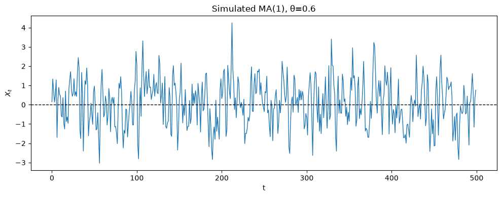

## MA(1): ACVF

$$\begin{align*}
\gamma_X(h) &= E[X_{t+h} X_t] \\
&= E\!\left[(Z_{t+h} + \theta Z_{t+h-1})(Z_t + \theta Z_{t-1})\right] \\
&= \begin{cases}
\sigma^2(1 + \theta^2) & h = 0 \\
\sigma^2 \theta & h = \pm 1 \\
0 & |h| > 1
\end{cases}
\end{align*}$$

**Key feature:** the ACF **cuts off** after lag 1.

These models have finite “memory.”

## MA(1): ACF

$$\rho_X(h) = \begin{cases}
1 & h = 0 \\
\dfrac{\theta}{1 + \theta^2} & h = \pm 1 \\
0 & |h| > 1
\end{cases}$$

A sharp cutoff in the sample ACF is the **signature of an MA model**.

Note: $|\rho_X(1)| = |\theta|/(1 + \theta^2) \leq 1/2$. The maximum one-lag correlation an MA(1) can produce is $1/2$, achieved at $|\theta| = 1$.

## MA(1): Visualizing the ACF

Simulate $X_t = Z_t + \theta Z_{t-1}$ and compare the **sample ACF** to the **theoretical ACF** derived above.

```python
from matplotlib.lines import Line2D
from statsmodels.graphics.tsaplots import plot_acf

# reuse the same simulated X, theta, n from the previous slide
lags = 15
rho_theory = np.zeros(lags + 1)
rho_theory[0] = 1
rho_theory[1] = theta / (1 + theta**2)

fig, ax = plt.subplots(figsize=(9, 5))
plot_acf(X, lags=lags, ax=ax, title=f"MA(1), θ={theta}: Sample vs. Theoretical ACF")
ax.scatter(range(lags + 1), rho_theory, color="red", zorder=5, label="Theoretical ACF")

sample_handle = Line2D([0], [0], color="C0", marker="o", label="Sample ACF")
theory_handle = Line2D([0], [0], color="red", marker="o", linestyle="", label="Theoretical ACF")
ax.legend(handles=[sample_handle, theory_handle])
plt.tight_layout()
plt.show()
```

The sample ACF (blue bars, with confidence bands) closely tracks the theoretical values (red dots) — a sharp drop to (near) zero after lag 1.

## MA(1): Visualizing the ACF

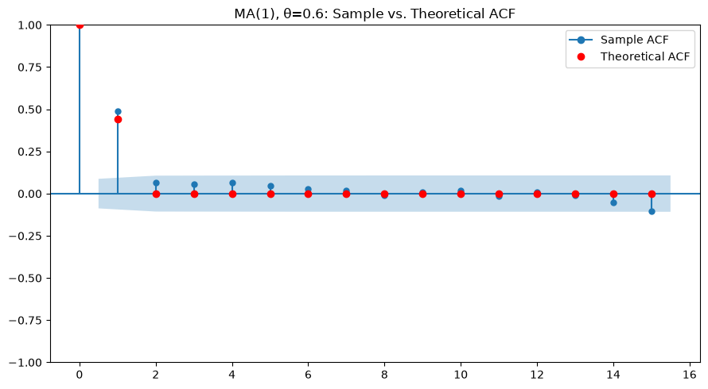

## Invertibility

An MA(1) is **invertible** if $|\theta| < 1$.

Invertibility ensures the model is **uniquely identifiable** from its ACVF. For any non-invertible MA model, there is an equivalent invertible one with the same ACVF but parameter $1/\theta$ instead of $\theta$.

In practice, estimation software always returns the invertible solution.

## MA(q): General Case

$$X_t = Z_t + \theta_1 Z_{t-1} + \cdots + \theta_q Z_{t-q}, \quad \{Z_t\} \sim \text{WN}(0, \sigma^2)$$

ACVF:
$$\gamma_X(h) = \sigma^2 \sum_{j=0}^{q - |h|} \theta_j \theta_{j + |h|}, \quad |h| \leq q \quad (\theta_0 = 1)$$

and $\gamma_X(h) = 0$ for $|h| > q$.

**The ACF of an MA($q$) is exactly zero beyond lag $q$.** This is the diagnostic used to identify $q$ from the sample ACF.

## Invertibility of MA($q$)

There is another (more complicated) way to ensure invertibility of an MA($q$) model, but writing the criterion requires discussing complex-valued polynomials. If you’re interested in learning about those, see the supplementary lecture.

It’s easy to miss the forest through the trees on this: it’s just a restriction of the parameter space so we don’t get two different models that yield that same acf plot.

It would be very rare to see someone use a non-invertible MA model. Software will (should) always restrict its attention to this situation. It’s just good to know that there is a restriction of the parameter space happening, though.

## MA(3): Simulated Time Series

What does an MA(3) path actually look like?

```python
import numpy as np
import matplotlib.pyplot as plt

np.random.seed(5005)
thetas = np.array([0.5, -0.3, 0.2])
q = len(thetas)
n = 500

Z = np.random.normal(size=n + q)
X = Z[q:].copy()
for j, theta in enumerate(thetas, start=1):
    X += theta * Z[q - j:n + q - j]

fig, ax = plt.subplots(figsize=(10, 4))
ax.plot(X, color="C0", lw=1)
ax.axhline(0, color="black", lw=1, ls="--")
ax.set_title(f"Simulated MA(3), θ={list(thetas)}")
ax.set_xlabel("t")
ax.set_ylabel(r"$X_t$")
plt.tight_layout()
plt.show()
```

## MA(3): Simulated Time Series

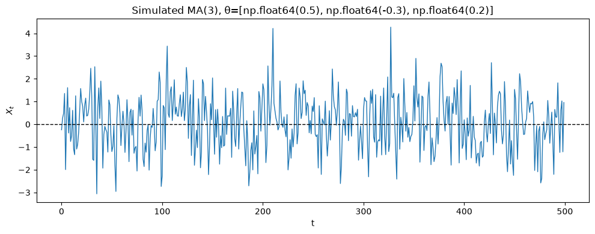

## MA(3): Visualizing the ACF

Simulate $X_t = Z_t + \theta_1 Z_{t-1} + \theta_2 Z_{t-2} + \theta_3 Z_{t-3}$ and compare the **sample ACF** to the **theoretical ACF**.

```python
from matplotlib.lines import Line2D
from statsmodels.graphics.tsaplots import plot_acf

# reuse the same simulated X, thetas, q, n from the previous slide
lags = 15
theta_full = np.concatenate(([1.0], thetas))
gamma_theory = np.array([
    np.sum(theta_full[: q - h + 1] * theta_full[h : q + 1]) if h <= q else 0.0
    for h in range(lags + 1)
])
rho_theory = gamma_theory / gamma_theory[0]

fig, ax = plt.subplots(figsize=(9, 5))
plot_acf(X, lags=lags, ax=ax, title=f"MA(3), θ={list(thetas)}: Sample vs. Theoretical ACF")
ax.scatter(range(lags + 1), rho_theory, color="red", zorder=5)

sample_handle = Line2D([0], [0], color="C0", marker="o", label="Sample ACF")
theory_handle = Line2D([0], [0], color="red", marker="o", linestyle="", label="Theoretical ACF")
ax.legend(handles=[sample_handle, theory_handle])
plt.tight_layout()
plt.show()
```

The sample ACF (blue bars, with confidence bands) closely tracks the theoretical values (red dots) — a sharp drop to (near) zero after lag 3.

## MA(3): Visualizing the ACF

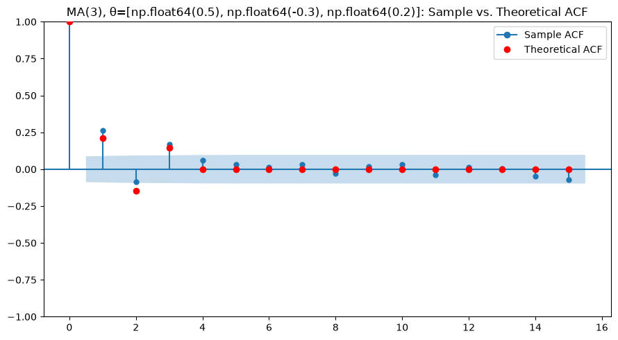

# Part 2: Autoregressive Models

## AR(1): First-Order Autoregression

Let $\{Z_t\} \sim \text{WN}(0, \sigma^2)$ with $|\phi| < 1$. The **AR(1)** model is:

$$X_t = \phi X_{t-1} + Z_t$$

- $\phi > 0$: positive autocorrelation (momentum / persistence)
- $\phi < 0$: negative autocorrelation (mean-reversion / oscillation)
- $\phi = 1$ random walk (nonstationary)

## AR(1): Simulated Time Series

Compare $\phi = 0.7$ (momentum) to $\phi = -0.7$ (oscillation).

```python
import numpy as np
import matplotlib.pyplot as plt

np.random.seed(5005)
n = 500
phis = [0.7, -0.7]

series = {}
for phi in phis:
    Z = np.random.normal(size=n)
    X = np.zeros(n)
    for t in range(1, n):
        X[t] = phi * X[t - 1] + Z[t]
    series[phi] = X

fig, axes = plt.subplots(2, 1, figsize=(10, 6), sharex=True)
for ax, phi in zip(axes, phis):
    ax.plot(series[phi], color="C0", lw=1)
    ax.axhline(0, color="black", lw=1, ls="--")
    ax.set_title(f"Simulated AR(1), φ={phi}")
    ax.set_ylabel(r"$X_t$")

axes[-1].set_xlabel("t")
plt.tight_layout()
plt.show()
```

## AR(1): Simulated Time Series

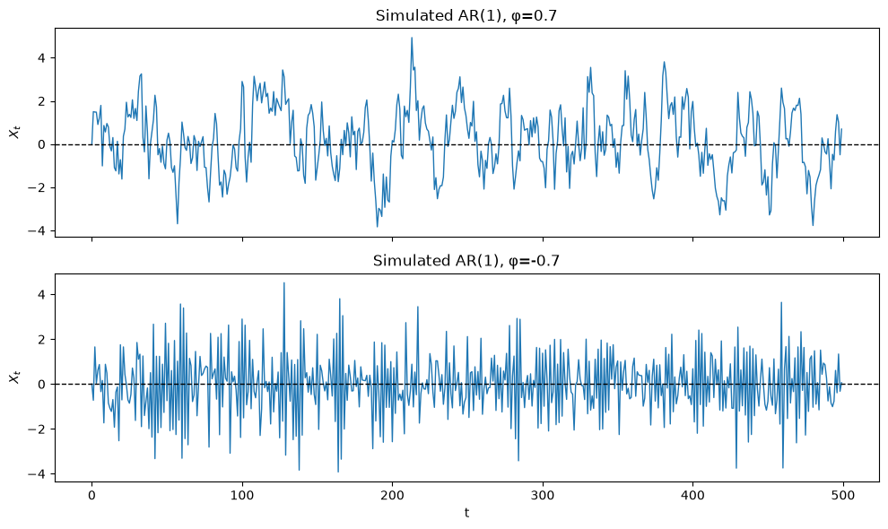

## AR(1): Stationarity via MA($\infty$) Representation

Under $|\phi| < 1$, repeatedly substituting the AR equation gives:

$$\begin{align*}
X_t &= \phi X_{t-1} + Z_t \\
&= \phi(\phi X_{t-2} + Z_{t-1}) + Z_t \\
&= Z_t + \phi Z_{t-1} + \phi^2 Z_{t-2} + \cdots \\
&= \sum_{j=0}^\infty \phi^j Z_{t-j}
\end{align*}$$

This is an MA($\infty$) representation with absolutely summable coefficients $\sum |\phi^j| = 1/(1 - |\phi|) < \infty$. When an AR process has such a representation, it is called **causal**.

## AR(1): ACVF and ACF

For the stationary AR(1):

$$\gamma_X(0) = \frac{\sigma^2}{1 - \phi^2}$$

For $h > 0$:

$$\begin{align*}
\gamma_X(h) &= E[X_{t+h} X_t] = E[(\phi X_{t+h-1} + Z_{t+h}) X_t] = \phi \gamma_X(h-1)
\end{align*}$$

Iterating: $\gamma_X(h) = \phi^h \gamma_X(0)$. So the ACF is:

$$\rho_X(h) = \phi^{|h|}$$

**Key feature:** the ACF **decays geometrically**, never cutting off.

## AR(1): Visualizing the ACF

Compare the **sample ACF** to the theoretical $\rho_X(h) = \phi^{|h|}$ for $\phi = 0.7$ and $\phi = -0.7$.

```python
from matplotlib.lines import Line2D
from statsmodels.graphics.tsaplots import plot_acf

# reuse the same simulated series, phis, n from the AR(1) time series slide
lags = 15

fig, axes = plt.subplots(1, 2, figsize=(12, 5))
for ax, phi in zip(axes, phis):
    rho_theory = phi ** np.arange(lags + 1)
    plot_acf(series[phi], lags=lags, ax=ax, title=f"AR(1), φ={phi}")
    ax.scatter(range(lags + 1), rho_theory, color="red", zorder=5)

sample_handle = Line2D([0], [0], color="C0", marker="o", label="Sample ACF")
theory_handle = Line2D([0], [0], color="red", marker="o", linestyle="", label="Theoretical ACF")
axes[0].legend(handles=[sample_handle, theory_handle])
plt.tight_layout()
plt.show()
```

The sample ACF tracks the theoretical geometric decay in both cases — note the **alternating sign** when $\phi < 0$, versus the smooth decay when $\phi > 0$. Unlike the MA case, there is no sharp cutoff.

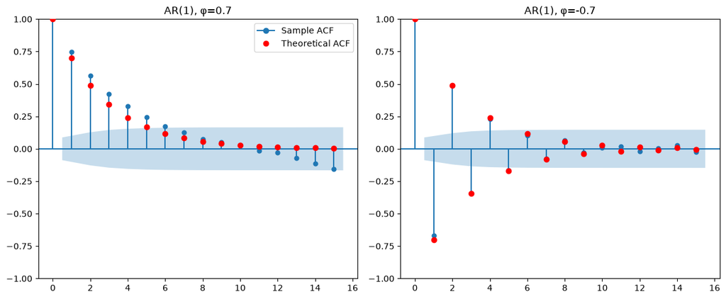

## AR(p): General Case

When we have an AR($p$)
$$X_t = \phi_1 X_{t-1} + \phi_2 X_{t-2} + \cdots + \phi_p X_{t-p} + Z_t$$

there is a way to restrict our attention to causal models. However, writing it down requires discussion of complex-valued polynomials. If you’re interested in learning about those, see the supplementary lecture.

Most of the time people work with causal models, just because it makes sense that we **don’t allow ourselves to condition on the future.**

## AR(2): Simulated Time Series

With complex-conjugate roots, an AR(2) can produce a **pseudo-periodic**, oscillating-but-decaying series.

```python
import numpy as np
import matplotlib.pyplot as plt

np.random.seed(5005)
n = 200
phi1, phi2 = 0.5, -0.7

Z = np.random.normal(size=n)
X = np.zeros(n)
for t in range(2, n):
    X[t] = phi1 * X[t - 1] + phi2 * X[t - 2] + Z[t]

fig, ax = plt.subplots(figsize=(10, 4))
ax.plot(X, color="C0", lw=1)
ax.axhline(0, color="black", lw=1, ls="--")
ax.set_title(f"Simulated AR(2), φ₁={phi1}, φ₂={phi2}")
ax.set_xlabel("t")
ax.set_ylabel(r"$X_t$")
plt.tight_layout()
plt.show()
```

## AR(2): Simulated Time Series

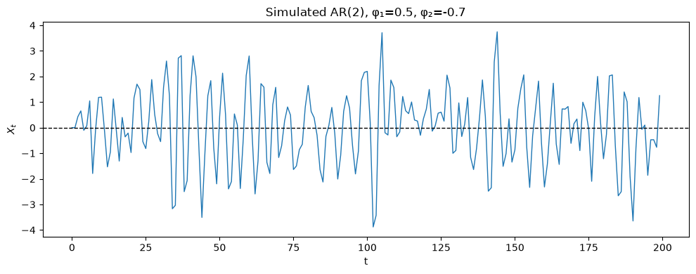

## AR(2): Visualizing the ACF

Compare the **sample ACF** to the theoretical ACF, obtained via the Yule-Walker recursion

$$\rho_X(1) = \frac{\phi_1}{1 - \phi_2}, \qquad \rho_X(h) = \phi_1 \rho_X(h-1) + \phi_2 \rho_X(h-2), \quad h \geq 2$$

```python
from matplotlib.lines import Line2D
from statsmodels.graphics.tsaplots import plot_acf

# reuse the same simulated X, phi1, phi2, n from the AR(2) time series slide
lags = 15
rho_theory = np.zeros(lags + 1)
rho_theory[0] = 1
rho_theory[1] = phi1 / (1 - phi2)
for h in range(2, lags + 1):
    rho_theory[h] = phi1 * rho_theory[h - 1] + phi2 * rho_theory[h - 2]

fig, ax = plt.subplots(figsize=(9, 5))
plot_acf(X, lags=lags, ax=ax, title=f"AR(2), φ₁={phi1}, φ₂={phi2}: Sample vs. Theoretical ACF")
ax.scatter(range(lags + 1), rho_theory, color="red", zorder=5)

sample_handle = Line2D([0], [0], color="C0", marker="o", label="Sample ACF")
theory_handle = Line2D([0], [0], color="red", marker="o", linestyle="", label="Theoretical ACF")
ax.legend(handles=[sample_handle, theory_handle])
plt.tight_layout()
plt.show()
```

The pseudo-periodic time series shows up in the ACF as a damped oscillation rather than a sharp cutoff — the signature of complex-conjugate roots. If you’re interested in learning about complex polynomials, see the supplementary lecture.

## AR(2): Visualizing the ACF

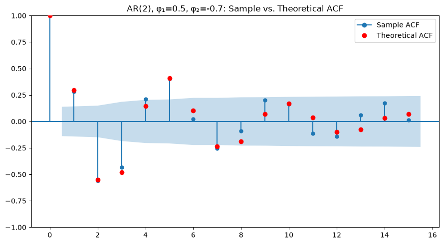

## The Partial Autocorrelation Function (PACF)

The **PACF** at lag $h$ measures the correlation between $X_t$ and $X_{t-h}$ **after removing the linear effect** of the intermediate observations $X_{t-1}, \ldots, X_{t-h+1}$.

Formally, it’s the coefficient on $X_{t-h}$ in the best linear predictor of $X_t$ from $X_{t-1}, \ldots, X_{t-h}$ (computable via the Durbin-Levinson recursion).

**Key feature:** for an AR($p$), the PACF is exactly zero beyond lag $p$.

- Intuition: once you regress $X_t$ on its own $p$ lags, you’ve captured everything the model says about the past — an additional lag adds nothing.
- This is the AR analogue of the ACF cutoff for MA($q$) models.

## PACF of the Simulated AR Models

Compare the **sample PACF** for AR(1), $\phi = 0.7$; AR(1), $\phi = -0.7$; and AR(2), $\phi_1 = 0.5, \phi_2 = -0.7$.

```python
from statsmodels.graphics.tsaplots import plot_pacf

# reuse series (AR(1) paths) and X (the AR(2) path) simulated earlier
lags = 15

fig, axes = plt.subplots(1, 3, figsize=(15, 4.5))
plot_pacf(series[0.7], lags=lags, ax=axes[0], title="AR(1), φ=0.7")
plot_pacf(series[-0.7], lags=lags, ax=axes[1], title="AR(1), φ=-0.7")
plot_pacf(X, lags=lags, ax=axes[2], title=f"AR(2), φ₁={phi1}, φ₂={phi2}")
plt.tight_layout()
plt.show()
```

Each PACF cuts off right after the true model order — lag 1 for the AR(1)s, lag 2 for the AR(2) — while the ACFs (previous slides) tail off geometrically instead.

## PACF of the Simulated AR Models

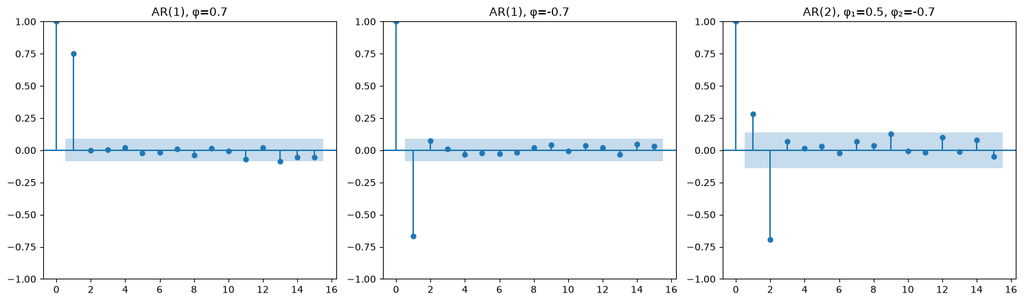

# Part 3: ARMA Models and ARIMA Models

## ARMA(p, q)

The **ARMA($p, q$)** model combines both:

$$X_t - \phi_1 X_{t-1} - \cdots - \phi_p X_{t-p} = Z_t + \theta_1 Z_{t-1} + \cdots + \theta_q Z_{t-q}$$

There are some technical restrictions on the parameter space. For more details see the supplementary lecture on complex polynomials.

## Why ARMA?

Pure AR or MA models can require many parameters to capture complicated ACF shapes.

An ARMA(1,1) may approximate data that would require AR(10) or MA(20) to describe. This is the **parsimony** principle: fewer parameters generalize better.

If you don’t have a compliated ACF/PACF, don’t worry about it. If you do, you’ll most likely use ARMA instead of a pure MA, or pure AR.

## ARIMA(p, d, q)

ARMA requires $\{X_t\}$ to already be stationary. Many series (e.g., (log-)price levels) aren’t. But their **differences** often are.

The **ARIMA($p, d, q$)** model applies ARMA($p, q$) to the series after differencing $d$ times. Let $W_t$ denote $X_t$ differenced $d$ times (e.g., $W_t = X_t - X_{t-1}$ when $d=1$). Then $\{W_t\}$ follows an ARMA($p,q$):

$$W_t - \phi_1 W_{t-1} - \cdots - \phi_p W_{t-p} = Z_t + \theta_1 Z_{t-1} + \cdots + \theta_q Z_{t-q}$$

**In practice:** $d=0$ recovers plain ARMA; $d=1$ models the differenced series (e.g., returns instead of prices); $d\ge2$ is rare.

We’ve been modeling AUD/JPY **returns** directly, which are already stationary — so $d=0$ and ARMA suffices. ARIMA becomes necessary if you instead want to model the non-stationary **price/spot level**.

# Part 4: Adding Deterministic Trend

## Why Extend ARMA?

Every model so far has assumed $E[X_t] = 0$ exactly, with no trend and no explanatory variables.

Real series have nonzero means, trends, and — often — other economic variables that help explain them. This part shows how those pieces attach to the same ARMA machinery instead of requiring a new theory.

The takeaway: ARMA is a **building block**, not a finished forecasting model on its own.

## Intercept vs. Mean: An Easy Mix-Up

Add a constant $c$ directly to the right-hand side of the ARMA equation — this is the **intercept**:

$$X_t = c + \phi_1 X_{t-1} + \cdots + \phi_p X_{t-p} + Z_t + \theta_1 Z_{t-1} + \cdots + \theta_q Z_{t-q}$$

Taking expectations of both sides (assuming stationarity, $d=0$) gives the **mean** $\mu = E[X_t]$:

$$\mu = c + \phi_1 \mu + \cdots + \phi_p \mu \quad\Longrightarrow\quad \mu = \frac{c}{1 - \phi_1 - \cdots - \phi_p}$$

**$c$ and $\mu$ are the same number only when $p = 0$** (pure MA, or white noise). Whenever there’s an AR component, the raw intercept and the long-run mean differ — and software isn’t always consistent about which one it reports or lets you fix, which is a common source of confusion when reading output.

## The Same Constant After Differencing

Now suppose $d \geq 1$ and we add a constant $c$ to the equation for the differenced series $W_t = X_t - X_{t-1}$:

$$W_t = c + \phi_1 W_{t-1} + \cdots + Z_t + \theta_1 Z_{t-1} + \cdots$$

By the same argument as above, $E[W_t] = c / (1 - \sum \phi_i)$ — a nonzero constant. Since $X_t = X_0 + \sum_{s \le t} W_s$, a nonzero mean for $W_t$ makes $X_t$ climb (or fall) by roughly that amount **every period** — a deterministic linear trend in the level, not just a fixed mean to revert to.

This is why it matters which equation the constant sits in: a constant in the $d=0$ (ARMA) equation gives you a forecast that reverts to a flat mean; the same constant in a $d\geq1$ (ARIMA) equation gives you a forecast that keeps sloping upward (or downward) indefinitely.

## Seeing It: ARMA(1,1) with an Intercept vs. Its Cumulative Sum

Simulate $X_t = c + \phi X_{t-1} + Z_t + \theta Z_{t-1}$, then plot $X_t$ itself next to $\sum_{s \leq t} X_s$ — the cumulative sum stands in for what happens once you integrate a $d\geq1$ model back up to the level series:

```python
import numpy as np
import matplotlib.pyplot as plt

np.random.seed(5005)
n = 300
phi, theta, c = 0.6, 0.4, 0.5
mu = c / (1 - phi)

Z = np.random.normal(size=n + 1)
X = np.zeros(n)
X[0] = mu + Z[1] + theta * Z[0]
for t in range(1, n):
    X[t] = c + phi * X[t - 1] + Z[t + 1] + theta * Z[t]

X_cumsum = np.cumsum(X)

fig, axes = plt.subplots(2, 1, figsize=(10, 7), sharex=True)
axes[0].plot(X, color="C0", lw=1)
axes[0].axhline(mu, color="black", ls="--", lw=1, label=fr"$\mu = {mu:.2f}$")
axes[0].set_title(f"ARMA(1,1) with intercept c={c}, φ={phi}, θ={theta}")
axes[0].set_ylabel(r"$X_t$")
axes[0].legend()

axes[1].plot(X_cumsum, color="C1", lw=1)
axes[1].set_title(r"Cumulative Sum, $\sum_{s \leq t} X_s$")
axes[1].set_xlabel("t")
axes[1].set_ylabel(r"$\sum_{s \leq t} X_s$")
plt.tight_layout()
plt.show()
```

The top panel is exactly what an ARMA intercept gives you: fluctuation around a fixed mean $\mu$, never trending away. The bottom panel — built by summing that same series — climbs roughly linearly, with slope $\approx \mu$. That’s the mechanism behind the previous slide: once you’re working with the level series (undoing a difference), a nonzero mean in the differenced series shows up as a deterministic trend in the level.

## Seeing It: ARMA(1,1) with an Intercept vs. Its Cumulative Sum

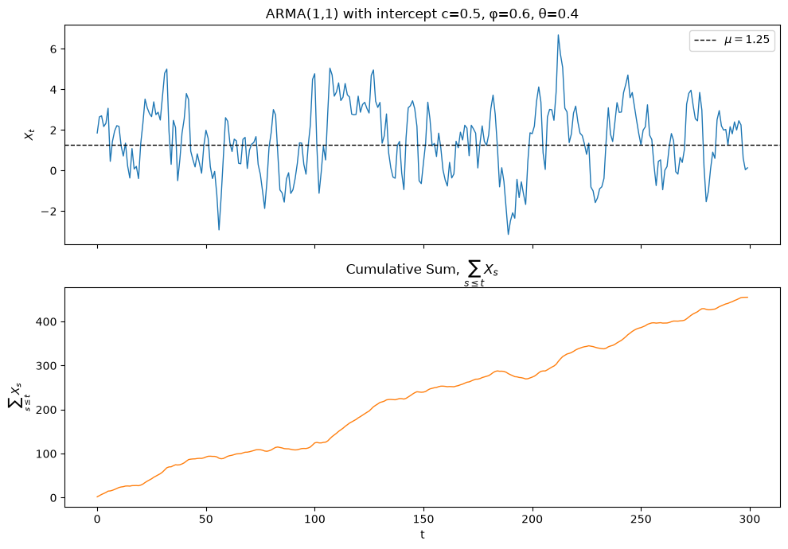

## Bringing in Predictors: Two Different Models

Suppose you also have predictor variables $Z_{1,t}, \ldots, Z_{k,t}$ (e.g., interest rate differentials, momentum signals) you’d like to use alongside ARMA structure. There are two genuinely different ways to combine them.

**Regression with ARMA errors:** the predictors explain the mean of $Y_t$; ARMA only cleans up whatever serial correlation is left in the noise:

$$Y_t = \beta_0 + \beta_1 Z_{1,t} + \cdots + \beta_k Z_{k,t} + \eta_t, \qquad \eta_t \sim \text{ARMA}(p, q)$$

**ARMAX:** the predictors sit directly on the right-hand side of the ARMA equation for $Y_t$ itself, alongside $Y_t$’s own lags:

$$Y_t = \phi_1 Y_{t-1} + \cdots + \phi_p Y_{t-p} + \beta_1 Z_{1,t} + \cdots + \beta_k Z_{k,t} + Z_t + \theta_1 Z_{t-1} + \cdots + \theta_q Z_{t-q}$$

## Why the Distinction Matters

In **regression with ARMA errors**, $\beta_j$ keeps its usual regression interpretation: holding the other predictors fixed, a one-unit change in $Z_{j,t}$ shifts $Y_t$’s mean by $\beta_j$, full stop. The ARMA part is confined to the error term and doesn’t touch that interpretation.

In **ARMAX**, $Y_{t-1}, \ldots, Y_{t-p}$ are themselves regressors — so a change in $Z_{j,t}$ doesn’t just move $Y_t$, it also propagates into $Y_{t+1}, Y_{t+2}, \ldots$ through the autoregressive feedback. $\beta_j$ is no longer a clean “holding everything else fixed” effect; the true effect of a change in $Z_j$ is a dynamic path, not a single number. (See Rob Hyndman’s write-up on this exact point: robjhyndman.com/hyndsight/arimax.)

**Default to regression with ARMA errors** unless you have a specific reason to want the feedback dynamics of ARMAX — it’s usually what people actually mean when they say they want to “add ARMA to a regression.”

## ARMA Is a Building Block, Not an Endpoint

Trend, exogenous predictors, and (next module) time-varying variance all **combine with** ARMA rather than replace it. The theory we’ve built — stationarity, ACF/PACF identification, invertibility — keeps paying off as we bolt on each extension.

# Part 5: Identification and Estimation

## ACF and PACF: The Identification Table

The **partial autocorrelation function (PACF)** at lag $h$ measures the correlation between $X_t$ and $X_{t-h}$ after removing the linear effect of all intermediate lags.

| Model | ACF | PACF |
| --- | --- | --- |
| MA($q$) | Cuts off after lag $q$ | Tails off (geometric) |
| AR($p$) | Tails off (geometric) | Cuts off after lag $p$ |
| ARMA($p,q$) | Tails off | Tails off |
| White noise | Near zero for $h > 0$ | Near zero for $h > 0$ |

Use this table to make an initial guess for $p$ and $q$, then use information criteria to refine.

## ACF and PACF in Python

```python
import numpy as np
import pandas as pd
import matplotlib.pyplot as plt
from statsmodels.graphics.tsaplots import plot_acf, plot_pacf

fx = pd.read_csv("../data/fx_rates.csv", index_col=0, parse_dates=True)
carry = np.log(fx["AUDJPY"]).diff().dropna() * 100

fig, axes = plt.subplots(1, 2, figsize=(12, 4))
plot_acf(carry, lags=20, ax=axes[0], title="Sample ACF: AUD/JPY Returns")
plot_pacf(carry, lags=20, ax=axes[1], title="Sample PACF: AUD/JPY Returns")
plt.tight_layout()
plt.show()
```

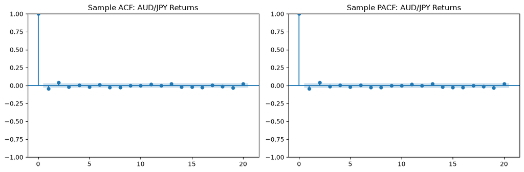

## Information Criteria

Rather than relying solely on ACF/PACF patterns, compare models with **information criteria**:

$$\text{AIC} = -2\log L(\hat{\boldsymbol{\theta}}) + 2k$$
$$\text{BIC} = -2\log L(\hat{\boldsymbol{\theta}}) + k \log n$$

where $k$ = number of parameters, $n$ = sample size, $\hat{\boldsymbol{\theta}}$ = MLE.

**Lower is better.** BIC penalizes complexity more than AIC — it tends to select smaller models.

## Fitting ARMA in Python

```python
from statsmodels.tsa.arima.model import ARIMA
import numpy as np
import pandas as pd

fx = pd.read_csv("../data/fx_rates.csv", index_col=0, parse_dates=True)
carry = np.log(fx["AUDJPY"]).diff().dropna() * 100

result = ARIMA(carry, order=(1, 0, 1)).fit()
print(result.summary())
```

```
                               SARIMAX Results
==============================================================================
Dep. Variable:                 AUDJPY   No. Observations:                 4381
Model:                 ARIMA(1, 0, 1)   Log Likelihood               -5116.311
Date:                Thu, 29 Oct 2026   AIC                          10240.623
Time:                        18:49:25   BIC                          10266.163
Sample:                             0   HQIC                         10249.634
                               - 4381
Covariance Type:                  opg
==============================================================================
                 coef    std err          z      P>|z|      [0.025      0.975]
------------------------------------------------------------------------------
const          0.0065      0.012      0.556      0.578      -0.016       0.030
ar.L1         -0.6780      0.109     -6.196      0.000      -0.892      -0.463
ma.L1          0.6325      0.116      5.472      0.000       0.406       0.859
sigma2         0.6052      0.007     82.769      0.000       0.591       0.620
===================================================================================
Ljung-Box (L1) (Q):                   0.08   Jarque-Bera (JB):              4144.35
Prob(Q):                              0.78   Prob(JB):                         0.00
Heteroskedasticity (H):               0.57   Skew:                            -0.54
Prob(H) (two-sided):                  0.00   Kurtosis:                         7.64
===================================================================================

Warnings:
[1] Covariance matrix calculated using the outer product of gradients (complex-step).
```

## Model Selection Over a Grid

```python
import warnings
import pandas as pd
import numpy as np
from statsmodels.tsa.arima.model import ARIMA

warnings.filterwarnings("ignore")

fx = pd.read_csv("../data/fx_rates.csv", index_col=0, parse_dates=True)
carry = np.log(fx["AUDJPY"]).diff().dropna() * 100

rows = []
for p in range(0, 4):
    for q in range(0, 4):
        try:
            m = ARIMA(carry, order=(p, 0, q)).fit()
            rows.append({"p": p, "q": q, "AIC": round(m.aic, 1), "BIC": round(m.bic, 1)})
        except Exception:
            pass

df = pd.DataFrame(rows)
print(df.sort_values("BIC").head(8).to_string(index=False))
```

## Model Selection Over a Grid

```
 p  q     AIC     BIC
 1  0 10246.8 10266.0
 0  0 10253.3 10266.1
 1  1 10240.6 10266.2
 0  1 10247.4 10266.6
 2  0 10242.1 10267.6
 0  2 10242.6 10268.1
 2  1 10242.3 10274.2
 1  2 10242.3 10274.2
```

## References

- Brockwell, P. J. & Davis, R. A. (2016). *Introduction to Time Series and Forecasting* (3rd ed.). Springer.